# Time Series Homework: Chapter 3 Lesson 3 Key

##### b) What parameters values did you choose for $\alpha$, $\beta$, and $\gamma$. Justify your choice.

**NoteAnswer**

There should be no long term trend to unemployment as it should fluctuate around a natural rate. Because of this we chose a $\beta$ that is close to zero (0.00008). However unemployment data does have some seasonality due to holiday hiring and college students looking for a job right after graduation. However the seasonality shouldn’t adjust much over time so we will chose a $\gamma$ of 0.03. An $\alpha$ of 0.001 was chosen as that level doesn’t change often and therefore should rely more on the historical data. Much of the fluctuations for this series comes from randomness and cycles.

##### c) Please plot the Holt-Winters forecast of the series for the next 24 months superimposed against the original series. Please see [Figure 7](https://byuistats.github.io/timeseries/chapter_3_lesson_3.html#fig-crime-hw-forecast) in Chapter 3: Lesson 3

**NoteAnswer**

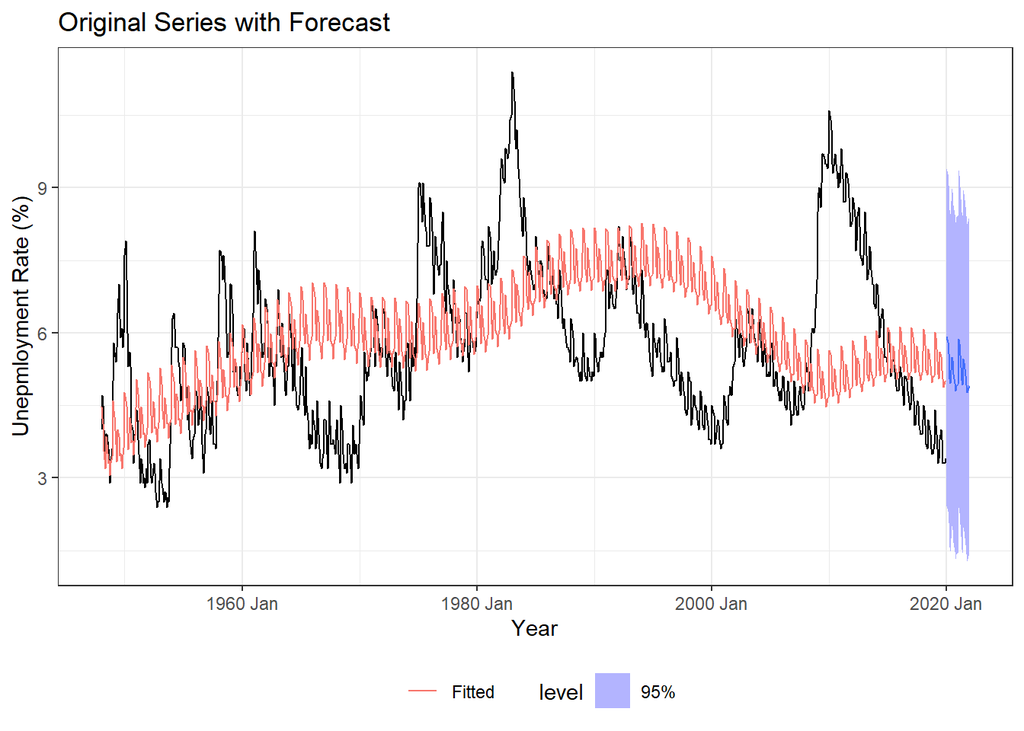

```r
unemp_hw |>
  forecast(h = "24 months") |>
  autoplot(unemp_ts, level = 95) +
  geom_line(aes(y = .fitted, color = "Fitted"),
    data = augment(unemp_hw)) +
  scale_color_discrete(name = "") +
  theme_bw() +
    labs(x = "Year",
         y = "Unepmloyment Rate (%)",
         color = "",
         title = "Original Series with Forecast")+
  theme(legend.position = "bottom")
```

### Question 2 - Additive Holt-Winters Forecasting: Evaluation (20 points)

##### a) The Unemployment Rate data stops at the end of 2019. Please access the latest data [HERE](https://fred.stlouisfed.org/series/UNRATENSA). Please don’t look at it until you have reached this point in the homework. Compare your forecasting work with with the actual realization of the series. What lessons about forecasting can you learn from the occurrence of [Gray Rhino](https://chatgpt.com/share/6712c9e5-4f58-8005-888d-acae9895bd05) events like a pandemic?

**NoteAnswer**

The forecasted unemployment rates for 2020 and 2021 anticipated stability, but COVID-19 caused actual rates to surge, diverging sharply from predictions. This highlights the grey rhino effect—a high-impact, foreseeable event often underestimated in risk assessment. While the pandemic’s risks were known, they were largely ignored in routine forecasts, underscoring a key limitation: standard models often fail to account for foreseeable shocks. This gap between forecasted and actual values emphasizes the need for forecasting frameworks to integrate “grey rhino” scenarios to better prepare for major, probable risks.

### Rubric

[output not shown]